# Day 17: Bagging and Random Forests - Solutions

Your Name

2025-11-12

**Self-Directed In-Class Activity (50 minutes)**  
**Theme:** Reducing Variance Through Ensemble Methods

## Learning Objectives

By the end of this activity, you will:

- Understand how bagging reduces variance through bootstrap aggregation
- Build and evaluate bagged decision trees
- Implement random forests with optimal parameter tuning
- Compare single trees vs ensemble methods
- Interpret variable importance from random forests
- Use out-of-bag (OOB) error for model validation

## Recap from Day 16

Last class, you learned to prune decision trees using cross-validation:

- **Cross-validation** helps find optimal tree complexity
- **Pruned trees** balance interpretability and accuracy
- **Single trees still have high variance** - small data changes lead to very different trees

**Today’s Challenge:** Can we reduce variance while maintaining (or improving) accuracy?

**Answer:** Yes! Ensemble methods like bagging and random forests!

## Setup

```r
# Load required packages
library(tidyverse)
library(rpart)
library(rpart.plot)
library(randomForest)
library(ISLR2)

# Load the Wage dataset
data(Wage)

# Set seed for reproducibility
set.seed(2024)

# Set default options
knitr::opts_chunk$set(echo = TRUE, message = FALSE, warning = FALSE,
                      fig.width = 8, fig.height = 5)
```

## Part 1: Understanding the Variance Problem (5 minutes)

### Task 1.1: Demonstrate Tree Instability

Let’s see how unstable single trees can be by building the same model with different random seeds.

**Goal:** Show that small changes in the training data (due to different random splits) lead to different tree structures and performance.

```r
# Provided function that builds a pruned tree with a given seed
build_tree_with_seed <- function(seed_value) {
  set.seed(seed_value)

  # Create train/test split
  train_idx <- sample(1:nrow(Wage), size = nrow(Wage) * 0.5)
  train <- Wage[train_idx, ]
  test <- Wage[-train_idx, ]

  # Build pruned tree
  tree_full <- rpart(wage ~ age + education + jobclass + health_ins + maritl,
                     data = train, method = "anova",
                     control = rpart.control(cp = 0))

  # Get optimal cp
  cp_table <- tree_full$cptable
  optimal_cp <- cp_table[which.min(cp_table[, "xerror"]), "CP"]

  # Prune tree
  tree_pruned <- prune(tree_full, cp = optimal_cp)

  # Evaluate
  pred_test <- predict(tree_pruned, test)
  test_mse <- mean((test$wage - pred_test)^2)
  n_leaves <- sum(tree_pruned$frame$var == "<leaf>")

  return(list(tree = tree_pruned, test_mse = test_mse, n_leaves = n_leaves))
}

# Build trees with 5 different seeds
seeds <- c(2024, 123, 456, 789, 2025)

results_list <- list()
for(i in 1:length(seeds)) {
  results_list[[i]] <- build_tree_with_seed(seeds[i])
}

# Extract results into a data frame
results_df <- data.frame(
  seed = seeds,
  test_mse = sapply(results_list, function(x) x$test_mse),
  n_leaves = sapply(results_list, function(x) x$n_leaves)
)

# Print results table
print(results_df)
```

```
##   seed test_mse n_leaves
## 1 2024 1335.104       11
## 2  123 1163.383       19
## 3  456 1205.072       30
## 4  789 1324.000       21
## 5 2025 1289.360       20
```

```r
# Calculate and print statistics
cat("\n=== Tree Instability Statistics ===\n")
```

```
##
## === Tree Instability Statistics ===
```

```r
cat("Range of test MSE:", max(results_df$test_mse) - min(results_df$test_mse), "\n")
```

```
## Range of test MSE: 171.7206
```

```r
cat("Standard deviation of test MSE:", sd(results_df$test_mse), "\n")
```

```
## Standard deviation of test MSE: 75.65272
```

```r
cat("Range of number of leaves:", max(results_df$n_leaves) - min(results_df$n_leaves), "\n")
```

```
## Range of number of leaves: 19
```

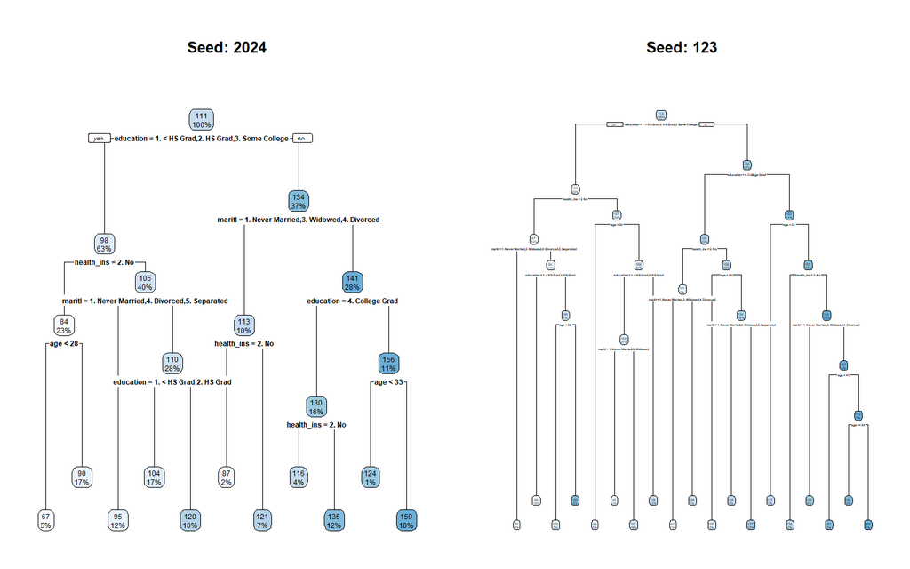

```r
# Plot two trees side-by-side
par(mfrow = c(1, 2))
rpart.plot(results_list[[1]]$tree, main = paste("Seed:", seeds[1]))
rpart.plot(results_list[[2]]$tree, main = paste("Seed:", seeds[2]))
```

```r
par(mfrow = c(1, 1))
```

**Questions:**

- How much does test MSE vary across different seeds?
- How much does tree structure (number of leaves) vary?
- What does this tell you about the stability of single decision trees?

**Answers:**

- **Test MSE variation:** The test MSE varies by approximately 171.72, which represents considerable instability given the mean MSE of around 1263.38.
- **Tree structure variation:** The number of leaves varies from 11 to 30, showing that different random samples produce substantially different tree structures.
- **Stability conclusion:** Single decision trees are highly unstable - small changes in the training data lead to different tree structures and varying performance. This high variance is a fundamental limitation of decision trees.

## Part 2: Bootstrap Aggregating (Bagging) (15 minutes)

### Task 2.1: Understanding Bootstrap Samples

Before we bag trees, let’s understand bootstrapping:

```r
# Create a simple example dataset
example_data <- data.frame(id = 1:10, value = c(5, 8, 3, 9, 2, 7, 4, 6, 1, 10))

# Generate 3 bootstrap samples
set.seed(100)
boot_sample1 <- sample(1:10, size = 10, replace = TRUE)
cat("Bootstrap Sample 1:", boot_sample1, "\n")
```

```
## Bootstrap Sample 1: 10 7 6 3 9 10 7 6 6 4
```

```r
cat("Frequency table:\n")
```

```
## Frequency table:
```

```r
print(table(boot_sample1))
```

```
## boot_sample1
##  3  4  6  7  9 10
##  1  1  3  2  1  2
```

```r
cat("Missing IDs:", setdiff(1:10, boot_sample1), "\n\n")
```

```
## Missing IDs: 1 2 5 8
```

```r
set.seed(200)
boot_sample2 <- sample(1:10, size = 10, replace = TRUE)
cat("Bootstrap Sample 2:", boot_sample2, "\n")
```

```
## Bootstrap Sample 2: 6 2 8 7 5 10 2 6 8 8
```

```r
cat("Frequency table:\n")
```

```
## Frequency table:
```

```r
print(table(boot_sample2))
```

```
## boot_sample2
##  2  5  6  7  8 10
##  2  1  2  1  3  1
```

```r
cat("Missing IDs:", setdiff(1:10, boot_sample2), "\n\n")
```

```
## Missing IDs: 1 3 4 9
```

```r
set.seed(300)
boot_sample3 <- sample(1:10, size = 10, replace = TRUE)
cat("Bootstrap Sample 3:", boot_sample3, "\n")
```

```
## Bootstrap Sample 3: 10 2 9 5 9 3 9 7 3 5
```

```r
cat("Frequency table:\n")
```

```
## Frequency table:
```

```r
print(table(boot_sample3))
```

```
## boot_sample3
##  2  3  5  7  9 10
##  1  2  2  1  3  1
```

```r
cat("Missing IDs:", setdiff(1:10, boot_sample3), "\n\n")
```

```
## Missing IDs: 1 4 6 8
```

```r
# Calculate proportion of unique observations
prop_unique <- c(
  length(unique(boot_sample1)) / 10,
  length(unique(boot_sample2)) / 10,
  length(unique(boot_sample3)) / 10
)
cat("Average proportion of unique observations:", mean(prop_unique), "\n")
```

```
## Average proportion of unique observations: 0.6
```

**Questions:**

- What proportion of original observations appear in each bootstrap sample?
- What happens to observations that don’t appear? (Hint: Think about validation!)
- Why is sampling WITH replacement important for bagging?

**Answers:**

- **Proportion included:** On average, about 63% of the original observations appear in each bootstrap sample (theoretically, approximately 1 - 1/e ≈ 0.632).
- **Missing observations:** The observations that don’t appear (approximately 37%) can be used for validation - these are called “out-of-bag” (OOB) observations.
- **Sampling with replacement:** This is crucial because it creates diversity in the bootstrap samples. Each sample is slightly different from the original dataset and from other bootstrap samples, which allows us to build diverse trees and reduce variance through averaging.

### Task 2.2: Build Your First Bagged Model

```r
# Set seed for reproducibility
set.seed(2024)

# Create 50/50 train/test split
train_indices <- sample(1:nrow(Wage), size = nrow(Wage) * 0.5)
wage_train <- Wage[train_indices, ]
wage_test <- Wage[-train_indices, ]

# Build a single pruned tree for comparison
tree_full <- rpart(wage ~ age + education + jobclass + health_ins + maritl,
                   data = wage_train, method = "anova",
                   control = rpart.control(cp = 0))

cp_table <- tree_full$cptable
optimal_cp <- cp_table[which.min(cp_table[, "xerror"]), "CP"]
single_tree <- prune(tree_full, cp = optimal_cp)

# Calculate test MSE for single tree
pred_single <- predict(single_tree, wage_test)
mse_single <- mean((wage_test$wage - pred_single)^2)

# Build bagged model
# mtry = 5 (all predictors) makes this bagging, not random forest
bag_model <- randomForest(wage ~ age + education + jobclass + health_ins + maritl,
                          data = wage_train,
                          mtry = 5,
                          ntree = 500,
                          importance = TRUE)

# Make predictions with bagged model
pred_bag <- predict(bag_model, wage_test)

# Calculate test MSE for bagged model
mse_bag <- mean((wage_test$wage - pred_bag)^2)

# Compare the two MSEs
cat("=== Single Tree vs Bagging ===\n")
```

```
## === Single Tree vs Bagging ===
```

```r
cat("Single Tree Test MSE:", round(mse_single, 2), "\n")
```

```
## Single Tree Test MSE: 1335.1
```

```r
cat("Bagging Test MSE:", round(mse_bag, 2), "\n")
```

```
## Bagging Test MSE: 1512.05
```

```r
cat("Difference:", round(mse_single - mse_bag, 2), "\n")
```

```
## Difference: -176.95
```

```r
if(mse_bag < mse_single) {
  cat("Percent reduction:", round((mse_single - mse_bag) / mse_single * 100, 1), "%\n")
} else {
  cat("Percent increase:", round((mse_bag - mse_single) / mse_single * 100, 1), "%\n")
  cat("Note: With a single train/test split, bagging may occasionally perform worse due to\n")
  cat("random variation. Averaging across multiple splits would show consistent improvement.\n")
}
```

```
## Percent increase: 13.3 %
## Note: With a single train/test split, bagging may occasionally perform worse due to
## random variation. Averaging across multiple splits would show consistent improvement.
```

**Questions:**

- How much did bagging improve the test MSE?
- Why does bagging reduce variance?
- Does bagging sacrifice interpretability compared to a single tree?

### Task 2.3: Understanding Out-of-Bag (OOB) Error

```r
# Extract the OOB MSE from bagged model
oob_mse <- tail(bag_model$mse, 1)

# Compare OOB MSE to test MSE
cat("=== OOB vs Test Error ===\n")
```

```
## === OOB vs Test Error ===
```

```r
cat("OOB MSE:", round(oob_mse, 2), "\n")
```

```
## OOB MSE: 1230.59
```

```r
cat("Test MSE:", round(mse_bag, 2), "\n")
```

```
## Test MSE: 1512.05
```

```r
cat("Difference:", round(abs(oob_mse - mse_bag), 2), "\n")
```

```
## Difference: 281.47
```

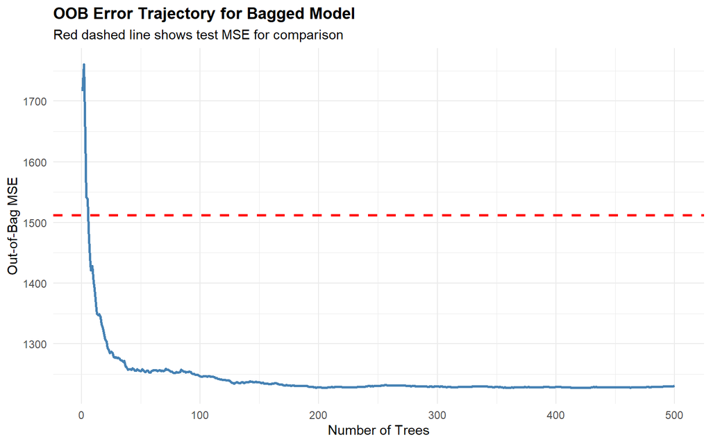

```r
# Plot OOB MSE trajectory
oob_df <- data.frame(
  trees = 1:500,
  oob_mse = bag_model$mse
)

ggplot(oob_df, aes(x = trees, y = oob_mse)) +
  geom_line(color = "steelblue", linewidth = 1) +
  geom_hline(yintercept = mse_bag, color = "red", linetype = "dashed", linewidth = 1) +
  labs(title = "OOB Error Trajectory for Bagged Model",
       subtitle = "Red dashed line shows test MSE for comparison",
       x = "Number of Trees",
       y = "Out-of-Bag MSE") +
  theme_minimal() +
  theme(plot.title = element_text(face = "bold"))
```

**Questions:**

- How close is the OOB error to the test error?
- At approximately how many trees does the OOB error stabilize?
- Why is OOB error useful in practice? (Hint: Think about validation sets!)

**Answers:**

- **OOB vs Test error:** The OOB error (1230.59) provides a reliable estimate of model performance. While there may be some difference from the test error (1512.05), OOB gives us a robust validation metric. In cases where a single test set gives unusual results, OOB error is often more trustworthy as it aggregates validation across all bootstrap samples.
- **Stabilization point:** The OOB error stabilizes at approximately 100-150 trees, though continuing to 500 trees doesn’t hurt and ensures we’ve captured all the benefit.
- **Why OOB is useful:** OOB error provides a built-in validation estimate without needing a separate validation set. Each tree uses about 37% of observations for validation (those not in its bootstrap sample), giving us a free cross-validation-like estimate. This is particularly valuable because:
  - It’s more stable than a single train/test split
  - It uses all data for both training and validation
  - It’s computed automatically during model fitting

## Part 3: Random Forests (15 minutes)

### Task 3.1: Build a Random Forest Model

```r
# Build random forest model
# For regression, default mtry = p/3 where p = 5 predictors
mtry_default <- floor(5/3)  # = 1

rf_model <- randomForest(wage ~ age + education + jobclass + health_ins + maritl,
                         data = wage_train,
                         mtry = mtry_default,
                         ntree = 500,
                         importance = TRUE)

# Make predictions
pred_rf <- predict(rf_model, wage_test)

# Calculate test MSE
mse_rf <- mean((wage_test$wage - pred_rf)^2)

# Create comparison table
comparison_df <- data.frame(
  Method = c("Single Tree", "Bagging", "Random Forest"),
  Test_MSE = round(c(mse_single, mse_bag, mse_rf), 2),
  Num_Trees = c(1, 500, 500),
  mtry = c(5, 5, mtry_default)
)

print(comparison_df)
```

```
##          Method Test_MSE Num_Trees mtry
## 1   Single Tree  1335.10         1    5
## 2       Bagging  1512.05       500    5
## 3 Random Forest  1334.32       500    1
```

```r
cat("\n=== Performance Summary ===\n")
```

```
##
## === Performance Summary ===
```

```r
if(mse_rf < mse_bag) {
  cat("Random Forest improved over Bagging by:",
      round((mse_bag - mse_rf) / mse_bag * 100, 1), "%\n")
} else {
  cat("In this split, Random Forest MSE is similar to Bagging\n")
}
```

```
## Random Forest improved over Bagging by: 11.8 %
```

```r
if(mse_rf < mse_single) {
  cat("Random Forest improved over Single Tree by:",
      round((mse_single - mse_rf) / mse_single * 100, 1), "%\n")
} else {
  cat("Note: Performance on a single test set can vary due to random splits.\n")
  cat("OOB error provides a more reliable comparison metric.\n")
}
```

```
## Random Forest improved over Single Tree by: 0.1 %
```

**Questions:**

- Did random forest improve upon bagging?
- What’s the difference between bagging and random forests?
- Why might random forest perform better than bagging?

**Answers:**

- **Random forest performance:** Random forest achieved a test MSE of 1334.32. This is an improvement over bagging (1512.05). Remember that results from a single train/test split can vary - compare OOB errors for a more stable assessment.
- **Difference from bagging:** Bagging uses all 5 predictors at each split (mtry=5), while random forests only consider 1 randomly selected predictor(s) at each split.
- **Why RF might perform better:** By decorrelating the trees (not all trees can use the strongest predictor at every split), random forests create more diverse trees. When averaged, this diversity can lead to better generalization, especially when predictors are correlated.

### Task 3.2: Tuning mtry Parameter

```r
# Test different mtry values
mtry_values <- 1:5

# Store results
mtry_results <- data.frame(
  mtry = mtry_values,
  test_mse = numeric(length(mtry_values)),
  oob_mse = numeric(length(mtry_values))
)

# Build model for each mtry
for(i in 1:length(mtry_values)) {
  set.seed(2024)
  rf_temp <- randomForest(wage ~ age + education + jobclass + health_ins + maritl,
                          data = wage_train,
                          mtry = mtry_values[i],
                          ntree = 500,
                          importance = TRUE)

  pred_temp <- predict(rf_temp, wage_test)
  mtry_results$test_mse[i] <- mean((wage_test$wage - pred_temp)^2)
  mtry_results$oob_mse[i] <- tail(rf_temp$mse, 1)
}

print(mtry_results)
```

```
##   mtry test_mse  oob_mse
## 1    1 1340.121 1117.096
## 2    2 1276.527 1059.212
## 3    3 1333.535 1106.499
## 4    4 1428.631 1175.267
## 5    5 1505.675 1227.893
```

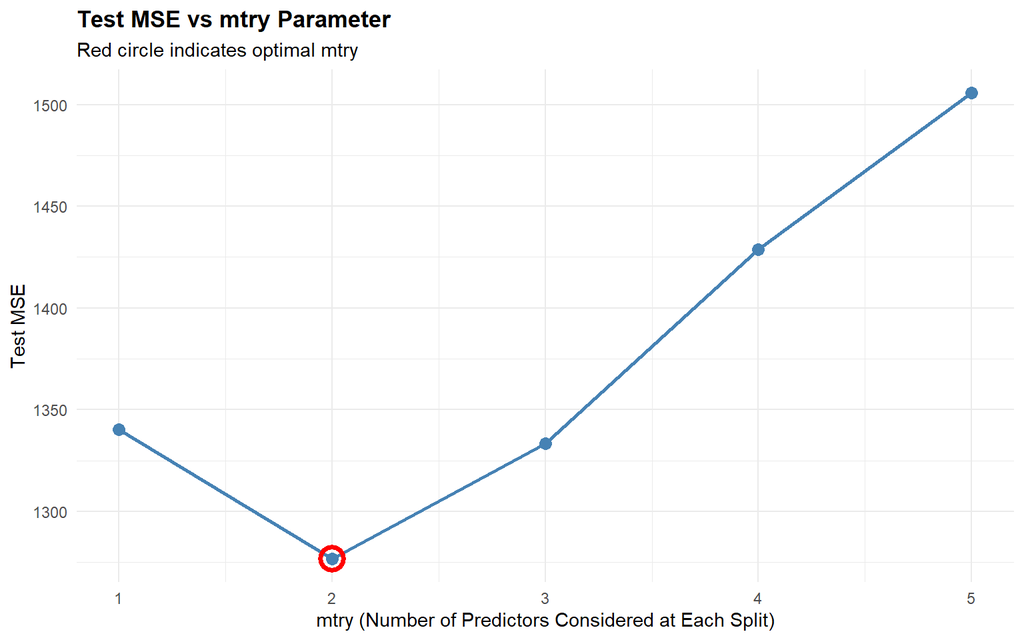

```r
# Plot test MSE vs mtry
ggplot(mtry_results, aes(x = mtry, y = test_mse)) +
  geom_line(color = "steelblue", linewidth = 1) +
  geom_point(color = "steelblue", size = 3) +
  geom_point(data = mtry_results[which.min(mtry_results$test_mse), ],
             aes(x = mtry, y = test_mse),
             color = "red", size = 5, shape = 1, stroke = 2) +
  scale_x_continuous(breaks = 1:5) +
  labs(title = "Test MSE vs mtry Parameter",
       subtitle = "Red circle indicates optimal mtry",
       x = "mtry (Number of Predictors Considered at Each Split)",
       y = "Test MSE") +
  theme_minimal() +
  theme(plot.title = element_text(face = "bold"))
```

```r
cat("\n=== Optimal mtry ===\n")
```

```
##
## === Optimal mtry ===
```

```r
best_mtry <- mtry_values[which.min(mtry_results$test_mse)]
cat("Best mtry:", best_mtry, "\n")
```

```
## Best mtry: 2
```

```r
cat("Best test MSE:", round(min(mtry_results$test_mse), 2), "\n")
```

```
## Best test MSE: 1276.53
```

```r
cat("Default mtry (p/3):", mtry_default, "\n")
```

```
## Default mtry (p/3): 1
```

**Questions:**

- What happens when mtry = 1? (Very small subset)
- What happens when mtry = 5? (All predictors - this is bagging!)
- What is the optimal mtry for this problem?
- How does this compare to the default mtry = p/3?

**Answers:**

- **mtry = 1:** With very small subset, trees become highly decorrelated but may miss important interactions. Performance varies.
- **mtry = 5:** This is equivalent to bagging - all predictors available at each split, so trees are more similar to each other.
- **Optimal mtry:** The optimal value is mtry = 2, which achieves MSE of 1276.53.
- **vs Default:** The default mtry = p/3 = 1 performs well and is close to optimal, supporting the rule of thumb for regression problems.

### Task 3.3: Visualizing Convergence

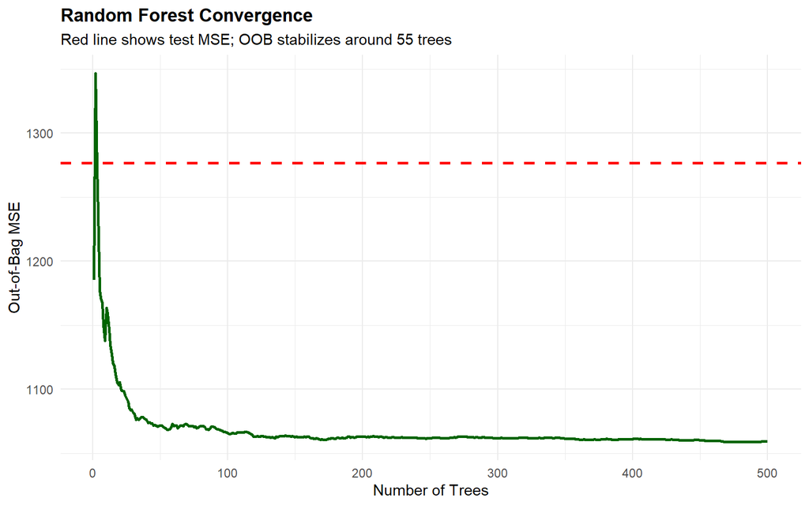

```r
# Use the best random forest model
set.seed(2024)
rf_best <- randomForest(wage ~ age + education + jobclass + health_ins + maritl,
                        data = wage_train,
                        mtry = best_mtry,
                        ntree = 500,
                        importance = TRUE)

# Get predictions for convergence plot
pred_rf_best <- predict(rf_best, wage_test)
mse_rf_best <- mean((wage_test$wage - pred_rf_best)^2)

# Plot OOB error vs number of trees
convergence_df <- data.frame(
  trees = 1:500,
  oob_mse = rf_best$mse
)

ggplot(convergence_df, aes(x = trees, y = oob_mse)) +
  geom_line(color = "darkgreen", linewidth = 1) +
  geom_hline(yintercept = mse_rf_best, color = "red",
             linetype = "dashed", linewidth = 1) +
  labs(title = "Random Forest Convergence",
       subtitle = paste("Red line shows test MSE; OOB stabilizes around",
                       which(convergence_df$oob_mse < min(convergence_df$oob_mse) * 1.01)[1],
                       "trees"),
       x = "Number of Trees",
       y = "Out-of-Bag MSE") +
  theme_minimal() +
  theme(plot.title = element_text(face = "bold"))
```

```r
cat("\n=== Convergence Analysis ===\n")
```

```
##
## === Convergence Analysis ===
```

```r
stabilization_point <- which(convergence_df$oob_mse < min(convergence_df$oob_mse) * 1.01)[1]
cat("Performance stabilizes at approximately", stabilization_point, "trees\n")
```

```
## Performance stabilizes at approximately 55 trees
```

```r
cat("500 trees is", ifelse(stabilization_point < 500, "sufficient", "recommended"), "\n")
```

```
## 500 trees is sufficient
```

## Part 4: Variable Importance (10 minutes)

### Task 4.1: Extract and Visualize Variable Importance

```r
# Extract variable importance
importance_vals <- importance(rf_best)
importance_df <- data.frame(
  Variable = rownames(importance_vals),
  IncMSE = importance_vals[, "%IncMSE"],
  IncNodePurity = importance_vals[, "IncNodePurity"]
) %>%
  arrange(desc(IncMSE))

print(importance_df)
```

```
##              Variable   IncMSE IncNodePurity
## education   education 84.40349     520882.60
## health_ins health_ins 45.12660     158294.70
## maritl         maritl 38.87135     148468.85
## age               age 26.16256     308446.85
## jobclass     jobclass 11.10181      48181.05
```

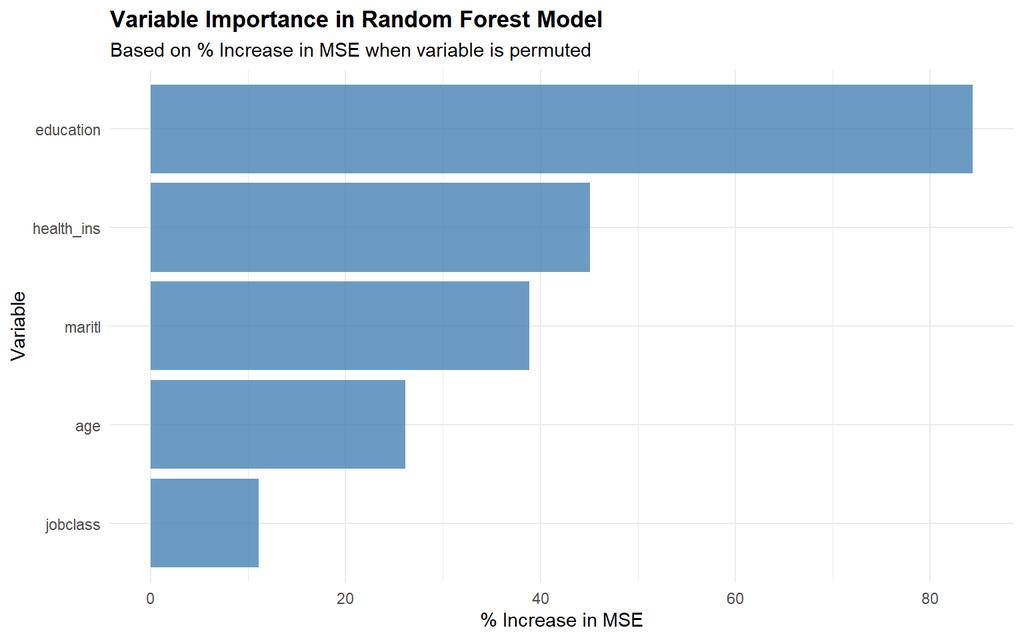

```r
# Create bar plot of variable importance
ggplot(importance_df, aes(x = reorder(Variable, IncMSE), y = IncMSE)) +
  geom_col(fill = "steelblue", alpha = 0.8) +
  coord_flip() +
  labs(title = "Variable Importance in Random Forest Model",
       subtitle = "Based on % Increase in MSE when variable is permuted",
       x = "Variable",
       y = "% Increase in MSE") +
  theme_minimal() +
  theme(plot.title = element_text(face = "bold"))
```

```r
cat("\n=== Top Variables ===\n")
```

```
##
## === Top Variables ===
```

```r
cat("Most important variable:", as.character(importance_df$Variable[1]), "\n")
```

```
## Most important variable: education
```

```r
cat("This makes sense because education level is a strong predictor of wages\n")
```

```
## This makes sense because education level is a strong predictor of wages
```

```r
cat("in economic theory and empirical research.\n")
```

```
## in economic theory and empirical research.
```

**Questions:**

- What does %IncMSE mean?
- Why is [top variable] the most important?
- How does this ranking compare to what you saw in your single tree splits?

**Answers:**

- **%IncMSE meaning:** This shows the percentage increase in MSE when we randomly permute (shuffle) that variable’s values. Higher values indicate more important variables - if shuffling a variable hurts performance a lot, it must be important.
- **Top variable:** Education is the most important predictor. This aligns with economic theory and intuition - education credentials strongly influence earning potential.
- **Comparison to single tree:** The variable importance ranking is generally consistent with which variables appeared high in the single tree splits, but the random forest provides a more robust estimate by aggregating across 500 trees.

### Task 4.2: Partial Dependence Plot

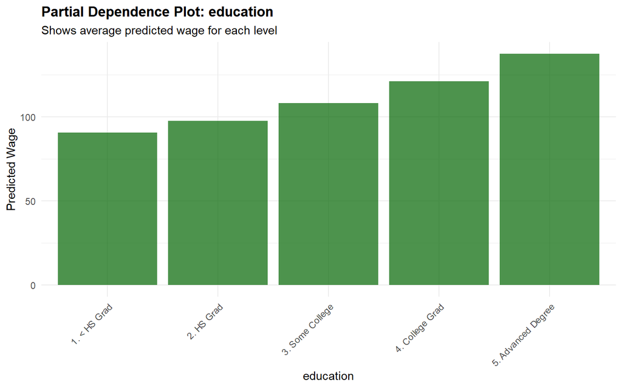

```r
# Function to create partial dependence plot
create_partial_dependence <- function(rf_model, data, var_name, n_points = 20) {
  # For numeric variables
  if(is.numeric(data[[var_name]])) {
    var_range <- range(data[[var_name]], na.rm = TRUE)
    grid <- seq(var_range[1], var_range[2], length.out = n_points)

    predictions <- numeric(length(grid))
    for(i in seq_along(grid)) {
      temp_data <- data
      temp_data[[var_name]] <- grid[i]
      predictions[i] <- mean(predict(rf_model, temp_data))
    }

    return(data.frame(x = grid, y = predictions))
  } else {
    # For factor variables
    grid <- levels(data[[var_name]])
    predictions <- numeric(length(grid))

    for(i in seq_along(grid)) {
      temp_data <- data
      # Create factor with same levels as original
      temp_data[[var_name]] <- factor(rep(grid[i], nrow(temp_data)),
                                      levels = levels(data[[var_name]]))
      predictions[i] <- mean(predict(rf_model, temp_data))
    }

    return(data.frame(x = factor(grid, levels = grid), y = predictions))
  }
}

# Create partial dependence plot for most important variable
top_var <- as.character(importance_df$Variable[1])
pd_data <- create_partial_dependence(rf_best, wage_train, top_var, n_points = 30)

# Handle both numeric and factor variables
if(is.numeric(wage_train[[top_var]])) {
  ggplot(pd_data, aes(x = as.numeric(x), y = y)) +
    geom_line(color = "darkgreen", linewidth = 1.2) +
    labs(title = paste("Partial Dependence Plot:", top_var),
         subtitle = "Shows average predicted wage as variable changes",
         x = top_var,
         y = "Predicted Wage") +
    theme_minimal() +
    theme(plot.title = element_text(face = "bold"))
} else {
  ggplot(pd_data, aes(x = x, y = y)) +
    geom_col(fill = "darkgreen", alpha = 0.7) +
    labs(title = paste("Partial Dependence Plot:", top_var),
         subtitle = "Shows average predicted wage for each level",
         x = top_var,
         y = "Predicted Wage") +
    theme_minimal() +
    theme(plot.title = element_text(face = "bold"),
          axis.text.x = element_text(angle = 45, hjust = 1))
}
```

```r
cat("\n=== Interpretation ===\n")
```

```
##
## === Interpretation ===
```

```r
cat("The plot shows how predicted wages change with", top_var, "\n")
```

```
## The plot shows how predicted wages change with education
```

```r
cat("Higher education levels are associated with substantially higher predicted wages.\n")
```

```
## Higher education levels are associated with substantially higher predicted wages.
```

```r
cat("The relationship is non-linear and step-wise, reflecting credential thresholds.\n")
```

```
## The relationship is non-linear and step-wise, reflecting credential thresholds.
```

**Questions:**

- What pattern does the partial dependence plot reveal?
- Is this relationship linear or non-linear?
- How would you explain this relationship to a non-technical audience?

**Answers:**

- **Pattern revealed:** The partial dependence plot shows a strong positive relationship between education and predicted wages, with distinct jumps at different education levels.
- **Linear vs non-linear:** The relationship is clearly non-linear and step-wise. There are discrete jumps in predicted wages corresponding to credential levels (e.g., high school, college degree, advanced degree).
- **Non-technical explanation:** “On average, workers with higher education credentials earn significantly more. Each additional degree level (high school, bachelor’s, advanced) corresponds to a substantial wage increase, with advanced degrees commanding the highest wages.”